# Yelp Text Mining Assignment 3

Joseline Tanujaya, Sweta Bansal, Vibhanshu

## Project Introduction

In this assignment we attempt to predict if a Yelp review (review on restaurants listed on the platform) is a positive or negative review. We will be using text mining with bag-of-words approach. In this assignment, we have made 27 predictions using 27 different approaches.

The best model out of the 27 is the SVM Broader Term model (in the table below, it is listed in row number 23). Please find below the complete tabulation of our records of the accuracy measures across all models. Our detailed codes, reasoning and description of approaches can be found in their respective sections.

Records of confusion matrices can be found in the **appendix** at the end the pdf document.

```r
print(read.csv("textmining_accuracies.csv"))
```

[output not shown]

```r
resReviewsData <- read_csv2('yelpRestaurantReviews_sample.csv')
```

```
## i Using ',' as decimal and '.' as grouping mark. Use `read_delim()` for more control.
```

```r
#glimpse(resReviewsData) #Check for data structure
```

## A. Data Exploration

The 5 different number of stars are distributed unevenly. Most of the reviews have 4 stars and 5 stars (with 14,042 and 16,091 reviews consequently). We are categorizing 1-2 stars as negative, and 4-5 stars as positive. We will later discared the 3 stars in building the models, because it is assumed as a “neutral” review.

###Analysis for words and stars

```r
library(tidytext) #for tokenization, removing stopwords
library(SnowballC)
library(textstem) #for stemming/lematization

#tokenize the text of the reviews in the column named 'text', selecting just the review_id and the text column
rrTokens <- resReviewsData %>% select(review_id, stars, text ) %>% unnest_tokens(word, text)

#How many tokens?
rrTokens %>% distinct(word) %>% dim()
```

```
## [1] 93440     1
```

```r
#remove stopwords
rrTokens <- rrTokens %>% anti_join(stop_words)
#compare with earlier - what fraction of tokens were stopwords?
rrTokens %>% distinct(word) %>% dim()
```

```
## [1] 92734     1
```

```r
#count the total occurrences of differet words, & sort by most frequent
rrTokens %>% count(word, sort=TRUE) %>% top_n(10)
```

```
## # A tibble: 10 x 2
##    word           n
##    <chr>      <int>
##  1 food       34397
##  2 service    16709
##  3 time       12537
##  4 restaurant 10877
##  5 chicken    10835
##  6 nice        8689
##  7 menu        8114
##  8 delicious   7690
##  9 pizza       7364
## 10 love        6983
```

```r
#Are there some words that occur in a large majority of reviews, or which are there in very few reviews?   Let's remove the words which are not present in at least 10 reviews
rareWords <-rrTokens %>% count(word, sort=TRUE) %>% filter(n<10)
xx<-anti_join(rrTokens, rareWords)

#check the words in xx ....
xx %>% count(word, sort=TRUE) %>% view()
#you will see that among the least frequently occurring words are those starting with or including numbers (as in 6oz, 1.15,...).  To remove these
xx2<- xx %>% filter(str_detect(word,"[0-9]")==FALSE)
   #the variable xx, xx2 are for checking ....if this is what we want, set the rrTokens to the reduced set of words.  And you can remove xx, xx2 from the environment.
rrTokens<- xx2
```

## B. Analyze words by star ratings

To analyze if some words are indicative of a positive or negative review, we summarise the average star ratings associated with each word, and then we find the occurences of the words across different ratings.

We eliminated the words that are used abundantly across all star-ratings (words like restaurant, food, time, service), because these words are not indicative of a positive/negative review.

After looking at the top words associated with a positive/negative review, we observe that most of the words in the positive and negative sentiments make sense, although some neutral words are labeled as positive like “chicken” - and “geno’s” labeled as negative.

To solve this, we further prune the set by excluding words that occur above 10,000 times. This threshold is decided by observing how many times words that do not make sense in the top 20 positive list occurs, without eliminating clearly positive/negative words. This threshold happens to be 10,000 (we can therefore avoid ‘chicken’ but retain the positive words in restaurant review context, like ‘love’).

```r
#Check words by star rating of reviews
rrTokens %>% group_by(stars) %>% count(word, sort=TRUE) %>% arrange(desc(stars)) %>% view()

#proportion of word occurrence by star ratings
ws <- rrTokens %>% group_by(stars) %>% count(word, sort=TRUE)
ws<-  ws %>% group_by(stars) %>% mutate(prop=n/sum(n))

#check the proportion of 'love' among reviews with 1,2,..5 stars
ws %>% filter(word=='love')
```

```
## # A tibble: 5 x 4
## # Groups:   stars [5]
##   stars word      n    prop
##   <dbl> <chr> <int>   <dbl>
## 1     5 love   3556 0.00742
## 2     4 love   2118 0.00413
## 3     3 love    701 0.00239
## 4     2 love    377 0.00204
## 5     1 love    231 0.00135
```

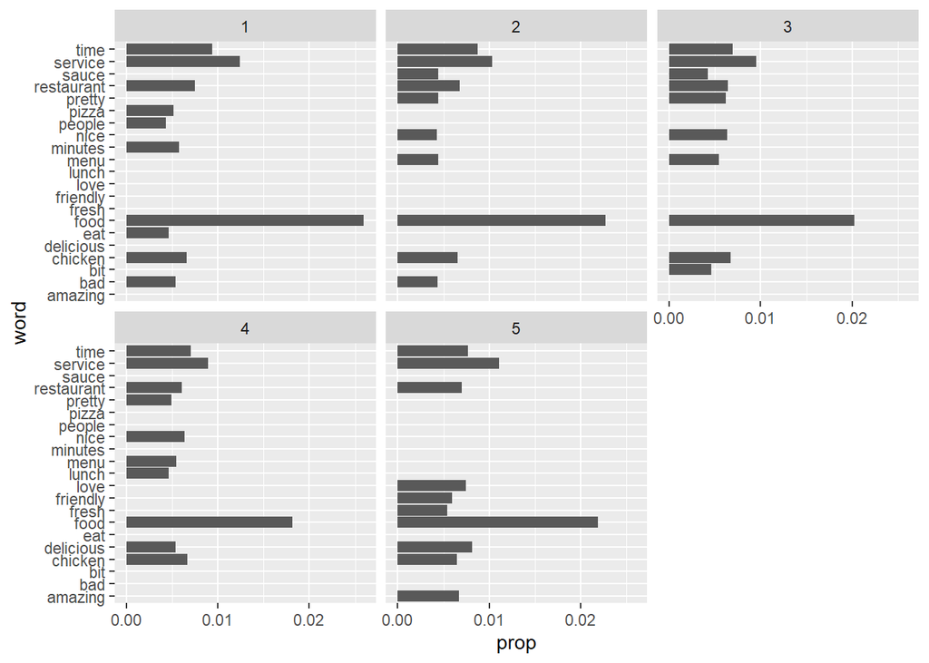

```r
#what are the most commonly used words by start rating
ws %>% group_by(stars) %>% arrange(stars, desc(prop)) %>% view()

#to see the top 20 words by star ratings
ws %>% group_by(stars) %>% arrange(stars, desc(prop)) %>% filter(row_number()<=20) %>% view()

#To plot this
ws %>% group_by(stars) %>% arrange(stars, desc(prop)) %>% filter(row_number()<=10) %>% ggplot(aes(word, prop))+geom_col()+coord_flip()+facet_wrap((~stars))
```

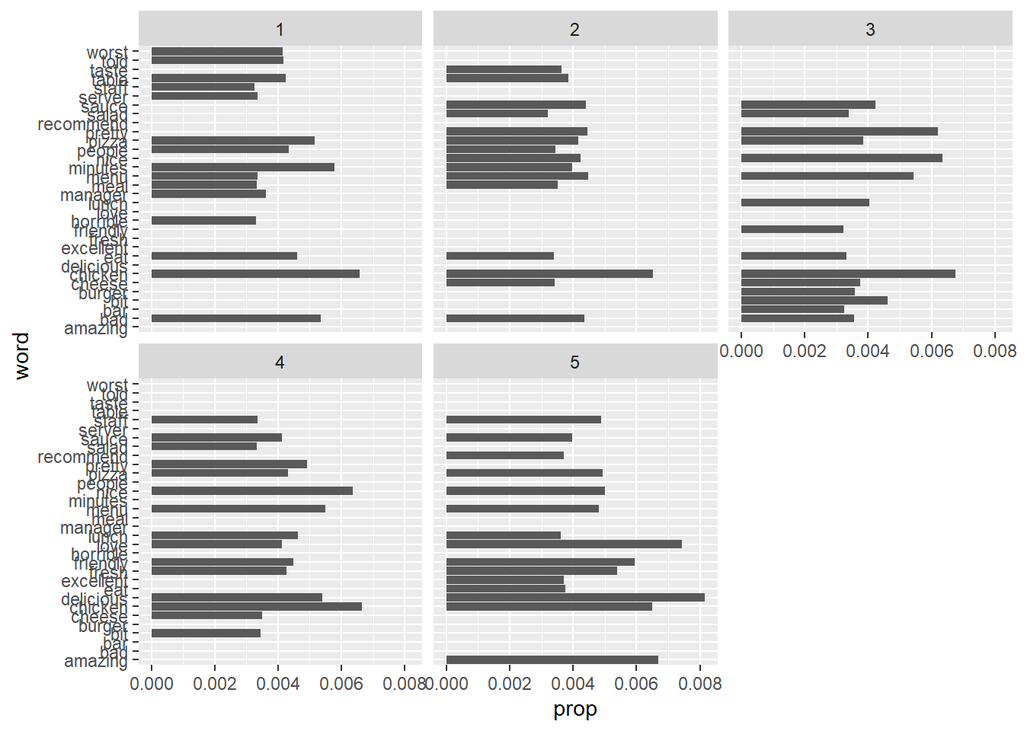

```r
#Alternatively separate plots by stars
#ws %>% filter(stars==1)  %>%  ggplot(aes(word, n)) + geom_col()+coord_flip()

# plot without words like ‘food’, ‘time’,… which occurs across ratings
ws %>% filter(! word %in% c('food', 'time', 'restaurant', 'service')) %>% group_by(stars) %>% arrange(stars, desc(prop)) %>% filter(row_number() <= 15) %>% ggplot(aes(word,prop)) + geom_col() + coord_flip() + facet_wrap((~stars))
```

```r
#Find which words are related to higher/lower star raings in general by calculating the average star rating associated with each word (sum the star ratings associated with reviews where each word occurs in, and then consider the proportion of each word among reviews with a star rating).
totWS_byword <- ws %>% group_by(word) %>% summarise(totWS=sum(stars*prop))
totWS_byword
```

```
## # A tibble: 11,285 x 2
##    word      totWS
##    <chr>     <dbl>
##  1 も    0.000185
##  2 也    0.000117
##  3 了    0.000109
##  4 人    0.0000963
##  5 味    0.000114
##  6 在    0.0000813
##  7 好    0.000105
##  8 是    0.0000904
##  9 的    0.000694
## 10 食    0.000107
## # ... with 11,275 more rows
```

```r
#What are the 20 words with highest and lowest star rating
totWS_byword %>% top_n(20)
```

```
## # A tibble: 20 x 2
##    word        totWS
##    <chr>       <dbl>
##  1 amazing    0.0493
##  2 cheese     0.0526
##  3 chicken    0.0990
##  4 delicious  0.0724
##  5 eat        0.0531
##  6 food       0.314
##  7 fresh      0.0578
##  8 friendly   0.0623
##  9 love       0.0662
## 10 lunch      0.0570
## 11 menu       0.0746
## 12 nice       0.0802
## 13 pizza      0.0670
## 14 pretty     0.0593
## 15 restaurant 0.0995
## 16 salad      0.0483
## 17 sauce      0.0611
## 18 service    0.153
## 19 staff      0.0550
## 20 time       0.114
```

```r
totWS_byword %>% top_n(-20)
```

```
## # A tibble: 20 x 2
##    word                totWS
##    <chr>               <dbl>
##  1 centric         0.0000740
##  2 choked          0.0000747
##  3 contacting      0.0000745
##  4 displeased      0.0000745
##  5 geno's          0.0000754
##  6 gristly         0.0000739
##  7 heed            0.0000756
##  8 inconvenienced  0.0000768
##  9 inconveniencing 0.0000753
## 10 infestation     0.0000730
## 11 minuscule       0.0000736
## 12 ohh             0.0000728
## 13 rainforest      0.0000708
## 14 refusing        0.0000765
## 15 resembling      0.0000763
## 16 resolution      0.0000693
## 17 santi           0.0000734
## 18 snapped         0.0000732
## 19 unsanitary      0.0000712
## 20 vomiting        0.0000680
```

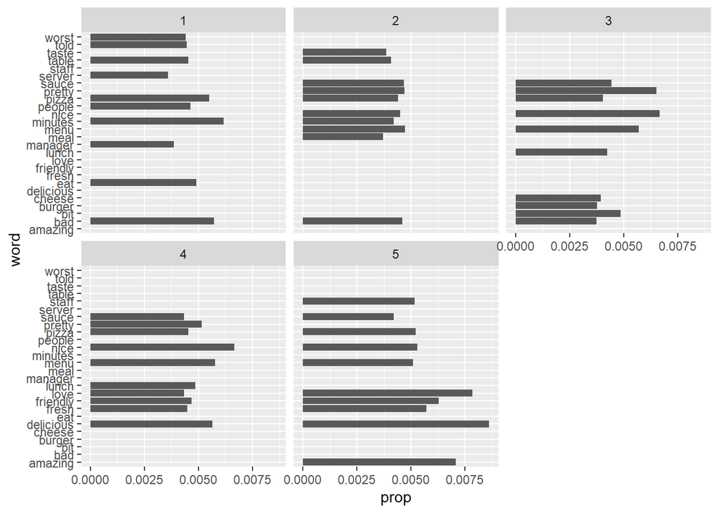

```r
   #Most of the words in the positive and negative sentiments make sense, although some neutral words are labeled as positive like "chicken" - and "geno's" labeled as negative.

#Further pruning the term set:
commonwords <-rrTokens %>% count(word, sort=TRUE) %>% filter(n>10000) #the threshold of 10,000 bcs we are trying to dispose of the some neutral words such as "chicken" that is mentioned accross all ratings.
rrTokens_wo_cw<-anti_join(rrTokens, commonwords)
rrTokens <- rrTokens_wo_cw

#proportion of word occurrence by star ratings
ws_afterprune <- rrTokens %>% group_by(stars) %>% count(word, sort=TRUE)
ws_afterprune<- ws_afterprune %>% group_by(stars) %>% mutate(prop=n/sum(n))

#to see the top 20 words by star ratings after pruning
ws_afterprune %>% group_by(stars) %>% arrange(stars, desc(prop)) %>% filter(row_number()<=20) %>% view()

#To plot this after pruning
ws_afterprune %>% group_by(stars) %>% arrange(stars, desc(prop)) %>% filter(row_number()<=10) %>% ggplot(aes(word, prop))+geom_col()+coord_flip()+facet_wrap((~stars))
```

```r
xx_afterprune<- ws_afterprune %>% group_by(word) %>% summarise(totWS=sum(stars*prop))
xx_afterprune
```

```
## # A tibble: 11,280 x 2
##    word      totWS
##    <chr>     <dbl>
##  1 も    0.000196
##  2 也    0.000124
##  3 了    0.000115
##  4 人    0.000102
##  5 味    0.000120
##  6 在    0.0000855
##  7 好    0.000111
##  8 是    0.0000955
##  9 的    0.000731
## 10 食    0.000112
## # ... with 11,270 more rows
```

```r
#What are the 20 words with highest and lowest star rating, after pruning.
xx_afterprune %>% top_n(20) #top words that occur in positive reviews
```

```
## # A tibble: 20 x 2
##    word       totWS
##    <chr>      <dbl>
##  1 amazing   0.0520
##  2 bit       0.0447
##  3 cheese    0.0554
##  4 delicious 0.0764
##  5 dinner    0.0457
##  6 eat       0.0561
##  7 fresh     0.0610
##  8 friendly  0.0657
##  9 love      0.0699
## 10 lunch     0.0601
## 11 meal      0.0508
## 12 menu      0.0787
## 13 nice      0.0845
## 14 night     0.0438
## 15 people    0.0479
## 16 pizza     0.0707
## 17 pretty    0.0625
## 18 salad     0.0509
## 19 sauce     0.0644
## 20 staff     0.0581
```

```r
xx_afterprune %>% top_n(-20) #top words that occur in negative reviews
```

```
## # A tibble: 20 x 2
##    word                totWS
##    <chr>               <dbl>
##  1 centric         0.0000778
##  2 choked          0.0000792
##  3 contacting      0.0000791
##  4 displeased      0.0000791
##  5 geno's          0.0000797
##  6 gristly         0.0000784
##  7 heed            0.0000798
##  8 inconvenienced  0.0000814
##  9 inconveniencing 0.0000799
## 10 infestation     0.0000776
## 11 minuscule       0.0000779
## 12 ohh             0.0000768
## 13 rainforest      0.0000749
## 14 refusing        0.0000810
## 15 resembling      0.0000808
## 16 resolution      0.0000736
## 17 santi           0.0000777
## 18 snapped         0.0000772
## 19 unsanitary      0.0000757
## 20 vomiting        0.0000723
```

```r
# There are less neutral words at the top 20. For example, "chicken" is no longer labeled as positive.
```

In order to progress to the next analysis, we will conduct Stemming and Lemmatization.

Stemming and Lemmatization

```r
rrTokens_stem<-rrTokens %>%  mutate(word_stem = SnowballC::wordStem(word))
rrTokens_lemm<-rrTokens %>%  mutate(word_lemma = textstem::lemmatize_words(word))

#Check the original words, and their stemmed-words and word-lemmas
```

Term-frequency, tf-idf

```r
rrTokens <- rrTokens %>%  mutate(word = textstem::lemmatize_words(word))

#We may want to filter out words with less than 3 characters and those with more than 15 characters
rrTokens <- rrTokens %>% filter(str_length(word)<=3 | str_length(word)<=15)

rrTokens<- rrTokens %>% group_by(review_id, stars) %>% count(word)

#count total number of words by review, and add this in a column
totWords<-rrTokens  %>% group_by(review_id) %>%  count(word, sort=TRUE) %>% summarise(total=sum(n))
rrTokens_totwords<-left_join(rrTokens, totWords)
  # now n/total gives the tf values
rrTokens_totwords<-rrTokens_totwords %>% mutate(tf=n/total)
head(rrTokens_totwords)
```

```
## # A tibble: 6 x 6
## # Groups:   review_id, stars [1]
##   review_id              stars word       n total    tf
##   <chr>                  <dbl> <chr>  <int> <int> <dbl>
## 1 --9qM_dRW4rrKTWO_SX_qQ     1 buffet     1     9 0.111
## 2 --9qM_dRW4rrKTWO_SX_qQ     1 copper     1     9 0.111
## 3 --9qM_dRW4rrKTWO_SX_qQ     1 kettle     1     9 0.111
## 4 --9qM_dRW4rrKTWO_SX_qQ     1 price      1     9 0.111
## 5 --9qM_dRW4rrKTWO_SX_qQ     1 soo        1     9 0.111
## 6 --9qM_dRW4rrKTWO_SX_qQ     1 star       1     9 0.111
```

```r
#We can use the bind_tfidf function to calculate the tf, idf and tfidf values
# (https://www.rdocumentation.org/packages/tidytext/versions/0.2.2/topics/bind_tf_idf)
rrTokens<-rrTokens %>% bind_tf_idf(word, review_id, n)
#head(rrTokens)
```

```r
#Broader Term Chunk
#First find out how many reviews each word occurs in
rWords<-rrTokens %>% group_by(word)%>% summarise(nr=n()) %>% arrange(desc(nr))
top_n(rWords, 20)
```

```
## # A tibble: 20 x 2
##    word         nr
##    <chr>     <int>
##  1 eat        8615
##  2 love       7544
##  3 price      7483
##  4 nice       7258
##  5 delicious  6665
##  6 menu       6583
##  7 friendly   6392
##  8 taste      6384
##  9 staff      5513
## 10 fry        5503
## 11 wait       5324
## 12 fresh      5299
## 13 sauce      5249
## 14 pretty     5187
## 15 meal       5052
## 16 bite       5013
## 17 lunch      4776
## 18 table      4776
## 19 drink      4684
## 20 bad        4642
```

```r
top_n(rWords, -20)
```

```
## # A tibble: 27 x 2
##    word         nr
##    <chr>     <int>
##  1 了            5
##  2 berto's       5
##  3 cardos        5
##  4 fukuda        5
##  5 kaak          5
##  6 lesbian       5
##  7 paladar       5
##  8 picarones     5
##  9 reggie's      5
## 10 wache         5
## # ... with 17 more rows
```

```r
#Remove words which occur in, for eg > 90% of reviews, and in less than 30 reviews
reduced_rWords<-rWords %>% filter(nr< 6000 & nr > 30)


#reduce the rrTokens data to keep only the reduced set of words
reduced_rrTokens <- left_join(reduced_rWords, rrTokens)
#Now convert it to a DTM, where each row is for a review (document), and columns are the terms (words)
revDTM <- reduced_rrTokens %>% pivot_wider(id_cols = c(review_id,stars), names_from = word, values_from = tf_idf) %>% ungroup()
#head(revDTM)


#create the dependent variable hiLo of good/bad reviews absed on stars, and remove the review with stars=3
revDTM <- revDTM %>% filter(stars!=3) %>% mutate(hiLo=ifelse(stars<=2, -1, 1)) %>% select(-stars)

revDTM<-revDTM %>% replace(., is.na(.), 0)
revDTM$hiLo<-as.factor(revDTM$hiLo)


#split the data into trn, tst subsets
set.seed(123)
nr=nrow(revDTM)
trnIndex = sample(1:nr, size = round(0.5*nr), replace=FALSE)
revDTM_SubSample=revDTM[trnIndex,]

library(rsample)
revDTM_split<- initial_split(revDTM_SubSample, 0.7)
revDTM_trn<- training(revDTM_split)
revDTM_inter<- testing(revDTM_split)

revDTM_split<- initial_split(revDTM_inter, 0.66)
revDTM_tst<- training(revDTM_split)
revDTM_valid<- testing(revDTM_split)

dim(revDTM_trn)
```

```
## [1] 14033  4208
```

```r
dim(revDTM_tst)
```

```
## [1] 3969 4208
```

```r
dim(revDTM_valid)
```

```
## [1] 2044 4208
```

```r
rm(revDTM_SubSample)
rm(revDTM_split)
rm(revDTM_inter)
rm(revDTM_sentiafinn_split_1)
library(ranger)

rfModel2<-ranger(dependent.variable.name = "hiLo", data=revDTM_trn %>% select(-review_id), num.trees = 500, importance='permutation', probability = TRUE)
#Obtain predictions, and calculate performance
revSenti_predTrn<- predict(rfModel2, revDTM_trn %>% select(-review_id))$predictions
revSenti_predValid<- predict(rfModel2,revDTM_valid %>% select(-review_id))$predictions
revSenti_predTst<- predict(rfModel2, revDTM_tst %>% select(-review_id))$predictions


#Confusion matrix
table(actual=revDTM_trn$hiLo, preds=revSenti_predTrn[,2]>0.5)
```

```
##       preds
## actual FALSE  TRUE
##     -1  3443    43
##     1      8 10539
```

```r
table(actual=revDTM_valid$hiLo, preds=revSenti_predValid[,2]>0.5)
```

```
##       preds
## actual FALSE TRUE
##     -1   332  195
##     1     43 1474
```

```r
table(actual=revDTM_tst$hiLo, preds=revSenti_predTst[,2]>0.5)
```

```
##       preds
## actual FALSE TRUE
##     -1   622  385
##     1     90 2872
```

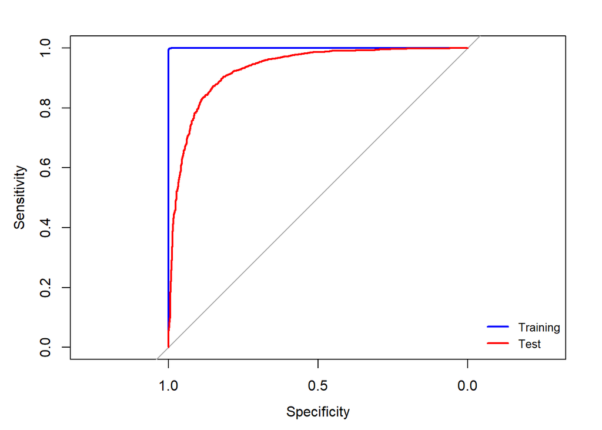

```r
#ROC AUC graph
library(pROC)
rocTrn_RFBT <- roc(revDTM_trn$hiLo, revSenti_predTrn[,2], levels=c(-1, 1))
rocTst_RFBT <- roc(revDTM_tst$hiLo, revSenti_predTst[,2], levels=c(-1, 1))
plot.roc(rocTrn_RFBT, col='blue')
plot.roc(rocTst_RFBT, col='red', add=TRUE)
legend("bottomright", legend=c("Training", "Test"),col=c("blue", "red"), lwd=2, cex=0.8, bty='n')
```